# PA1_template.Rmd

Ajit Dhamale

September 18, 2016

```r
library(data.table)
library(ggplot2)
```

# Loading and preprocessing the data

### set working directory to directory where files are downloaded

### download the input data zip file

```r
setwd(".")
url <- "https://d396qusza40orc.cloudfront.net/repdata%2Fdata%2Factivity.zip"
zipName <- file.path(getwd(), "input_data.zip")
download.file(url, zipName)
unzip(zipName, overwrite = TRUE)
```

### Load the input csv in a data table and Lets look at the dimensions of input data

```r
csvdata <- data.table::fread("activity.csv")
dim(csvdata)
```

```
## [1] 17568     3
```

# What is mean total number of steps taken per day?

### now lets count steps per day by removing the NAs in the input data

```r
spd <- csvdata[,sum(as.numeric(steps), na.rm = TRUE), by=date]
```

# Plot histograms of steps per day

# fig

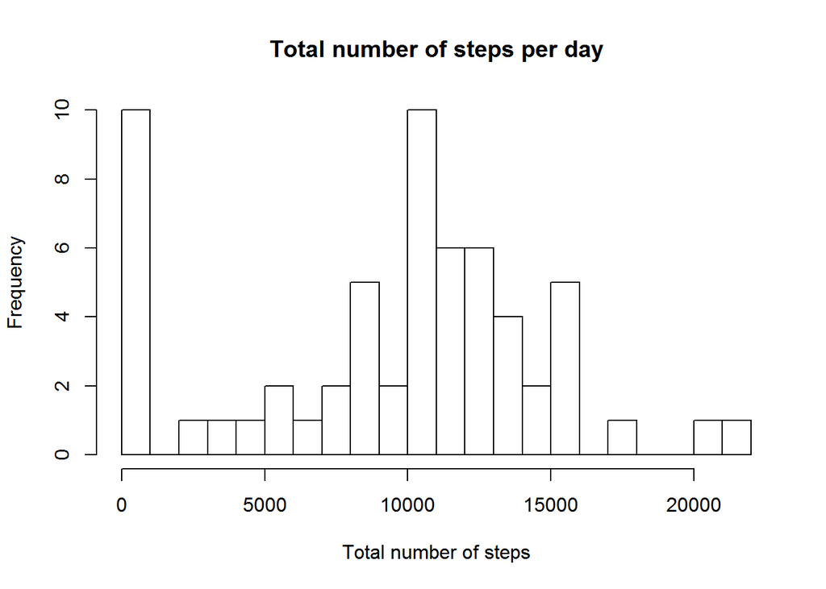

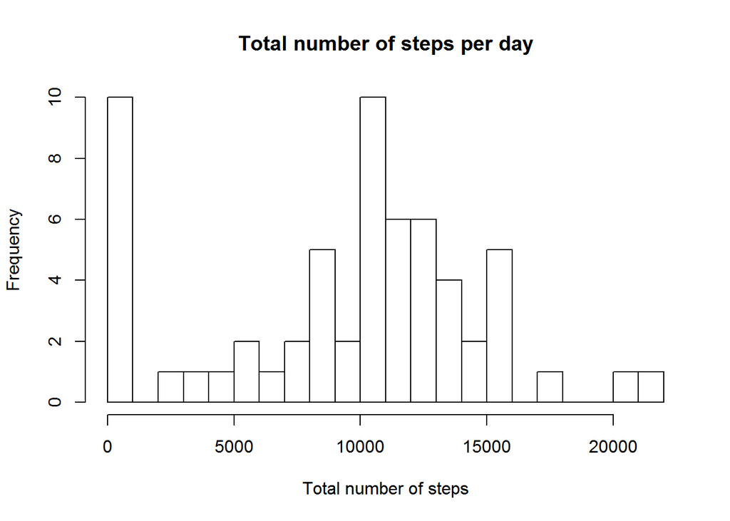

# report mean

```r
print(mean(spd$V1, na.rm =  TRUE))
```

```
## [1] 9354.23
```

# report median

```r
print(median(spd$V1, na.rm =  TRUE))
```

```
## [1] 10395
```

# What is the average daily activity pattern?

### Make a time series plot (i.e. type = “l”) of the 5-minute interval (x-axis)

### and the average number of steps taken, averaged across all days (y-axis)

### so first calculate the mean steps per interval across all days

```r
spi <- csvdata[,mean(as.numeric(steps), na.rm = TRUE), by=interval]
```

### now plot the average steps per interval across all days

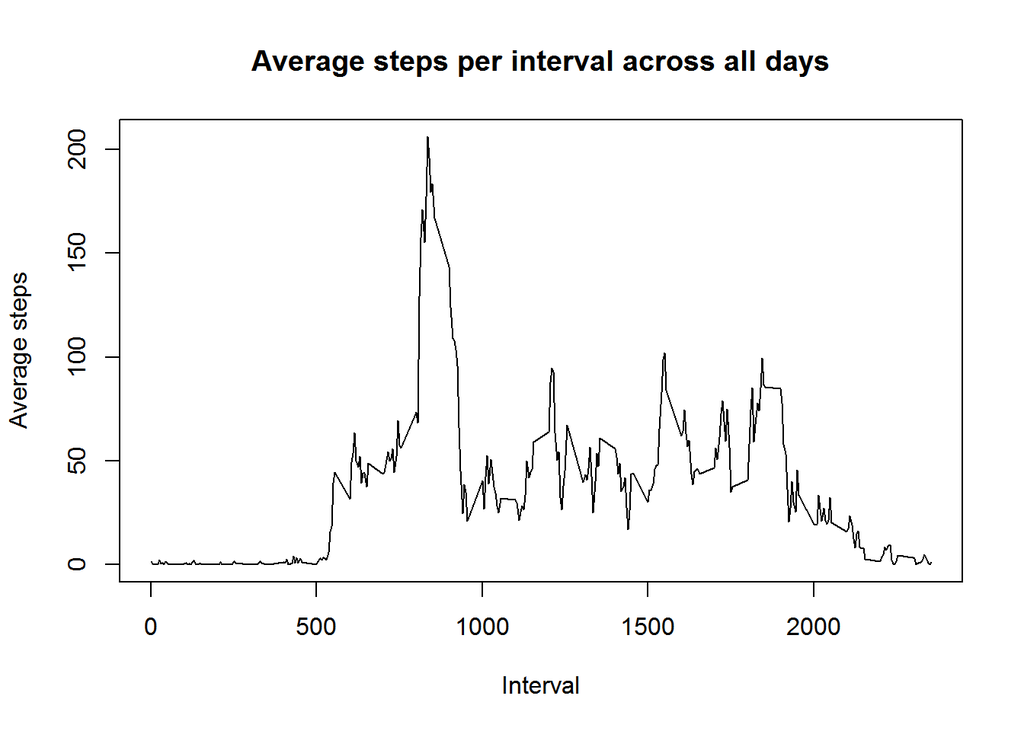

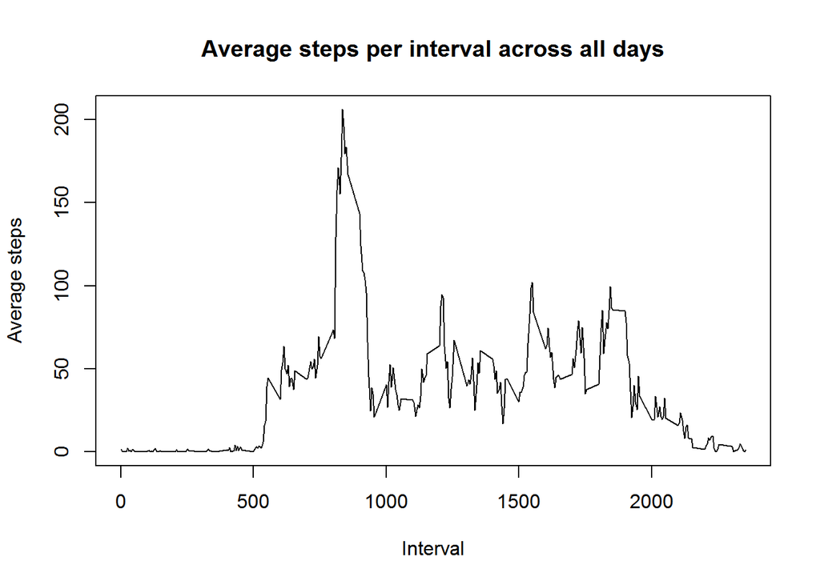

# Which 5-minute interval, on average across all the days in the dataset, contains the maximum number of steps?

### Find out interval with maximum steps

```r
intWithMaxSteps <- spi[which.max(spi$V1),]
print(intWithMaxSteps)
```

```
##    interval       V1
## 1:      835 206.1698
```

# Imputing missing values

### Calculate and report the total number of missing values in the dataset (i.e. the total number of rows with NAs)

### Number of missing step values is

```r
no_of_nas <- length((which(is.na(csvdata$steps))))
print(no_of_nas)
```

```
## [1] 2304
```

### total number of values as a percent

```r
total_no_of_rows <- nrow(csvdata)
print( ( no_of_nas * 100 ) / total_no_of_rows)
```

```
## [1] 13.11475
```

### Strategy to fill misssing values is to fill NAs with mean of that interval across days

### tempData has original numberof steps and average number

```r
tempData <- merge(csvdata,spi, by.x = "interval",by.y = "interval", all.x = TRUE, sort=FALSE)
```

### rename new merged column V1 to average_steps

```r
names(tempData)[names(tempData) =="V1"] <- "average_steps"
```

### now add imputed_steps column to tempdata

```r
tempData$imputed_steps <- NA
```

### Create a new dataset that is equal to the original dataset but with the missing data filled in

### set value of imputed steps to average stpes if steps is NA else set to steps

```r
tempData$imputed_steps <- ifelse(is.na(tempData$steps), tempData$average_steps, tempData$steps )
imputedData <- tempData
```

### now lets count steps per day by removing the NAs in the input data

```r
spdImputedData <- imputedData[,sum(as.numeric(imputed_steps), na.rm = TRUE), by=date]
```

# Make a histogram of the total number of steps taken each day using imputed data

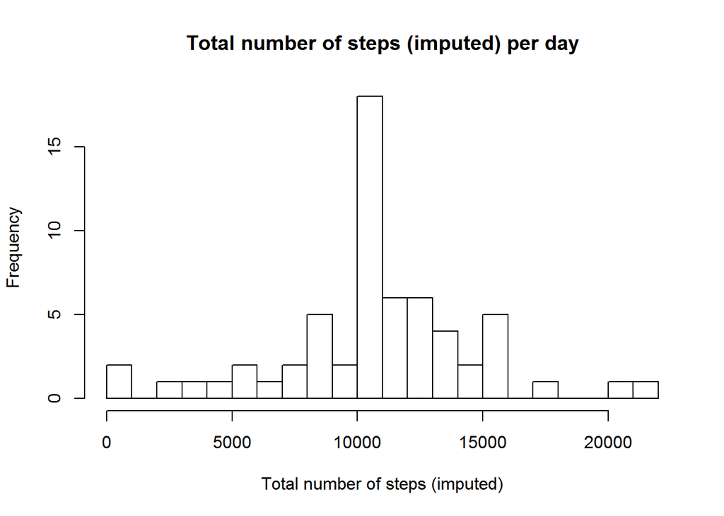

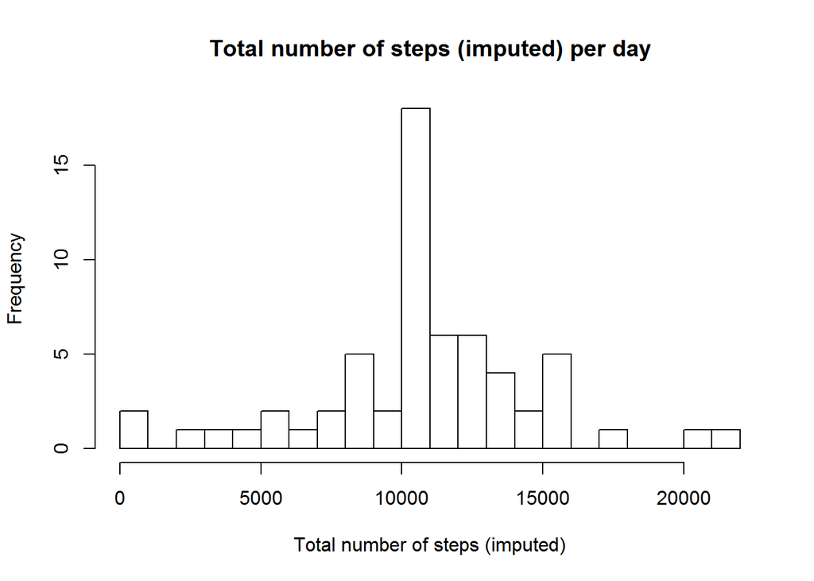

# report mean for imputed data

```r
print(mean(spdImputedData$V1, na.rm =  TRUE))
```

```
## [1] 10766.19
```

# report median for imputed data

```r
print(median(spdImputedData$V1, na.rm =  TRUE))
```

```
## [1] 10766.19
```

### note that mean and median has increased after filling in the missing values

# Are there differences in activity patterns between weekdays and weekends?

### add day column based on date

```r
imputedData$day <- weekdays(as.Date(imputedData$date), abbreviate =  TRUE)
```

### add factor column to identify weekdays

```r
imputedData$is_weekday <- as.factor(!( imputedData$day  == "Sun" | imputedData$day == "Sat"))
```

```r
spiImputedData <- imputedData[,mean(as.numeric(steps), na.rm = TRUE), by=interval]
```

# Create a new factor variable in the dataset with two levels - “weekday” and “weekend”

### Now calculate the average number of steps per interval for WEEKDAYS

```r
cw <- imputedData[which(imputedData$is_weekday == TRUE ),mean(as.numeric(steps), na.rm = TRUE), by=interval]
```

### For the results assign factor ‘weekday’

```r
cw$day_type <- as.factor("Weekday")
```

### Now calculate the average number of steps per interval for WEEKENDS days

```r
cwknd <- imputedData[which(imputedData$is_weekday == FALSE ),mean(as.numeric(steps), na.rm = TRUE), by=interval]
```

### For the results assign factor ‘Weekend’

```r
cwknd$day_type <- as.factor("Weekend")
```

### finally combine the average steps per interval for weekdays and weekends in a single data frame

```r
finalData <- rbindlist(list(cw,cwknd))
```

### Now plot the results for Average number of steps per interval, add facets for day_type

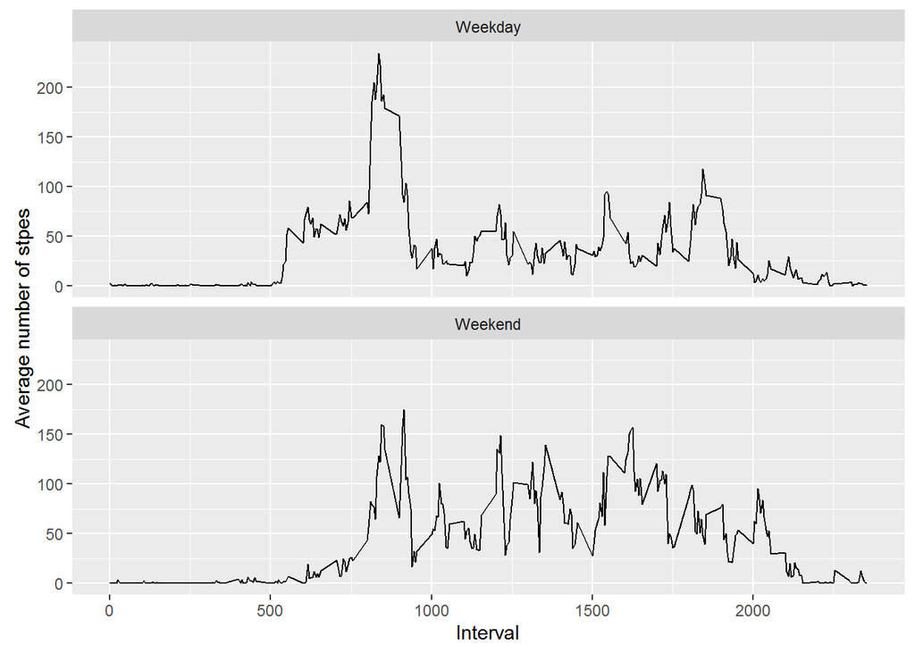

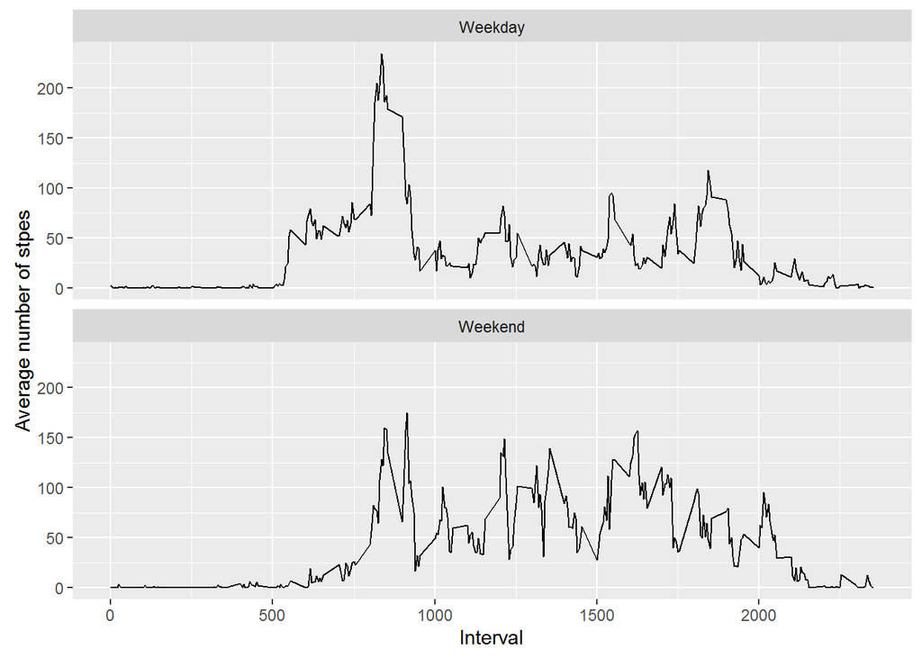